# Titanic

Vien Nguyen

7 Aug 2016

# 1 Prerequisite

## 1.1 Set working directory and import datasets

```r
setwd("/Users/tvnguyen/Research/Titanic")
train <- read.csv("datasets/train.csv")
test <- read.csv("datasets/test.csv")
```

## 1.2 Load required packages for machine learning

```r
library(ggplot2) # visualization
library(ggthemes) # visualization
library(scales) # visualization
library(dplyr) # manipulation
library(mice) # imputation
library(caret)
library(e1071)
library(rpart)
library(randomForest)
library(party)
```

## 1.3 Join together the training/test sets for feature engineering

```r
test$Survived <- NA
combi <- rbind(train, test)
```

## 1.4 Check data

```r
str(combi)
```

```
## 'data.frame':    1309 obs. of  12 variables:
##  $ PassengerId: int  1 2 3 4 5 6 7 8 9 10 ...
##  $ Survived   : int  0 1 1 1 0 0 0 0 1 1 ...
##  $ Pclass     : int  3 1 3 1 3 3 1 3 3 2 ...
##  $ Name       : Factor w/ 1307 levels "Abbing, Mr. Anthony",..: 109 191 358 277 16 559 520 629 417 581 ...
##  $ Sex        : Factor w/ 2 levels "female","male": 2 1 1 1 2 2 2 2 1 1 ...
##  $ Age        : num  22 38 26 35 35 NA 54 2 27 14 ...
##  $ SibSp      : int  1 1 0 1 0 0 0 3 0 1 ...
##  $ Parch      : int  0 0 0 0 0 0 0 1 2 0 ...
##  $ Ticket     : Factor w/ 929 levels "110152","110413",..: 524 597 670 50 473 276 86 396 345 133 ...
##  $ Fare       : num  7.25 71.28 7.92 53.1 8.05 ...
##  $ Cabin      : Factor w/ 187 levels "","A10","A14",..: 1 83 1 57 1 1 131 1 1 1 ...
##  $ Embarked   : Factor w/ 4 levels "","C","Q","S": 4 2 4 4 4 3 4 4 4 2 ...
```

# 2 Feature Engineering

## 2.1 Engineer variable: Name

```r
combi$Name <- as.character(combi$Name)
```

### Split name to: Title, Surname

```r
combi$Title <- sapply(combi$Name, FUN=function(x) {strsplit(x, split='[,.]')[[1]][2]})
combi$Surname <- sapply(combi$Name, FUN=function(x) {strsplit(x, split='[,.]')[[1]][1]})
combi$Title <- sub(' ', '', combi$Title)
```

### Combine similar titles together

```r
combi$Title[combi$Title %in% c('Mme', 'Mlle', 'Ms', 'Miss')] <- 'Miss'
combi$Title[combi$Title %in% c('Rev', 'Dr')] <- 'Rev'
combi$Title[combi$Title %in% c('Capt', 'Don', 'Major', 'Sir')] <- 'Sir'
combi$Title[combi$Title %in% c('Dona', 'Lady', 'the Countess', 'Jonkheer')] <- 'Lady'
```

### Convert to a factor

```r
combi$Title <- factor(combi$Title)
```

## 2.2 Engineered variable: Family size

```r
combi$FamilySize <- combi$SibSp + combi$Parch + 1
```

### Use ggplot2 to visualize the relationship between family size & survival

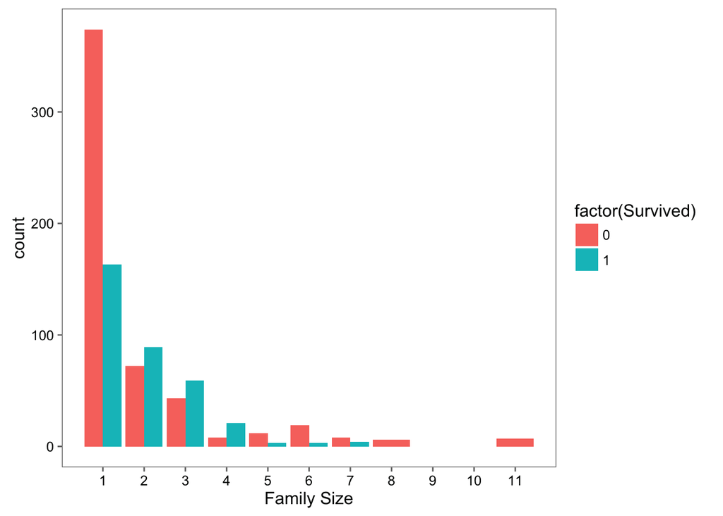

```r
ggplot(combi[1:891,], aes(x = FamilySize, fill = factor(Survived))) +
  geom_bar(stat='count', position='dodge') +
  scale_x_continuous(breaks=c(1:11)) +
  labs(x = 'Family Size') +
  theme_few()
```

## 2.3 Engineered variable: Family

```r
combi$FamilyID <- paste(as.character(combi$FamilySize), combi$Surname, sep="")
```

### Discretize family size

```r
combi$FamilyID[combi$FamilySize == 1] <- 'Singleton'
combi$FamilyID[1 < combi$FamilySize & combi$FamilySize <= 3] <- 'Small'
combi$FamilyID[3 < combi$FamilySize & combi$FamilySize <= 5] <- 'Normal'
combi$FamilyID[combi$FamilySize > 5] <- 'Large'
```

### Delete erroneous family IDs

```r
famIDs <- data.frame(table(combi$FamilyID))
famIDs <- famIDs[famIDs$Freq <= 2,]
combi$FamilyID[combi$FamilyID %in% famIDs$Var1] <- 'Small'
```

### Convert to a factor

```r
combi$FamilyID <- factor(combi$FamilyID)
```

### Show family size by survival using a mosaic plot

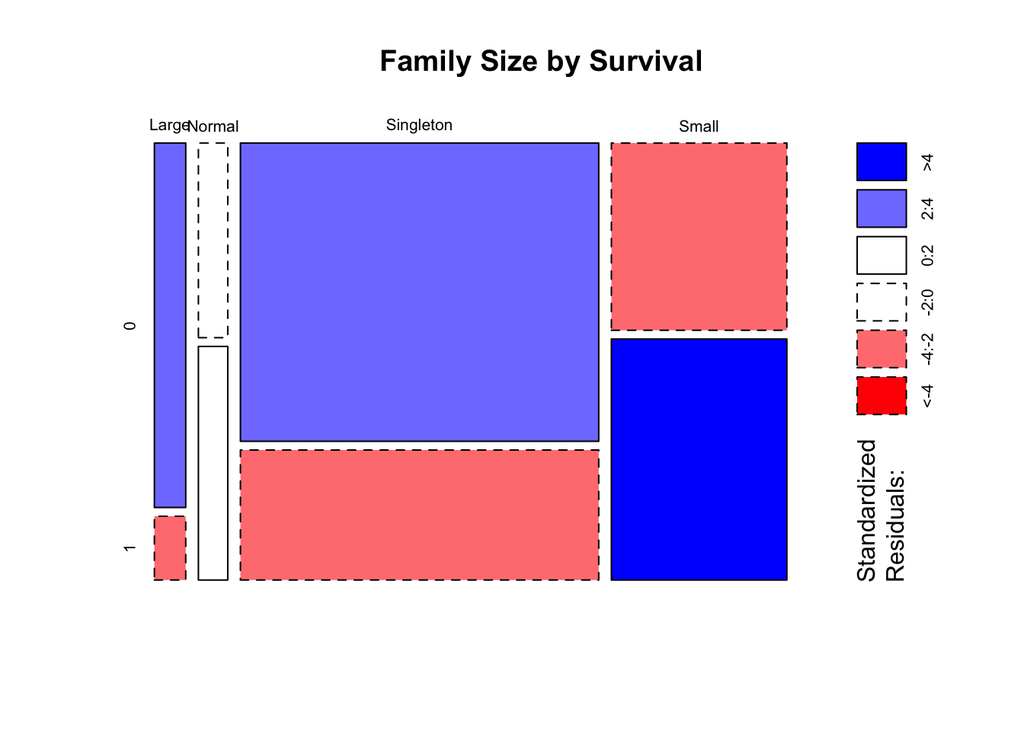

```r
mosaicplot(table(combi$FamilyID, combi$Survived), main='Family Size by Survival', shade=TRUE)
```

# 3 Impute Missing Values and More Feature Engineering

## 3.1 Fill in Missing Values

### 3.1.1 Fill in Embarked blanks

### Find Embarked blanks

```r
summary(combi$Embarked)
```

```
##       C   Q   S
##   2 270 123 914
```

```r
which(combi$Embarked == '')
```

```
## [1]  62 830
```

### Get rid of our missing passenger IDs

```r
Embark_Fare <- combi %>%
  filter(PassengerId != 62 & PassengerId != 830)
```

### Use ggplot2 to visualize embarkment, passenger class, & median fare

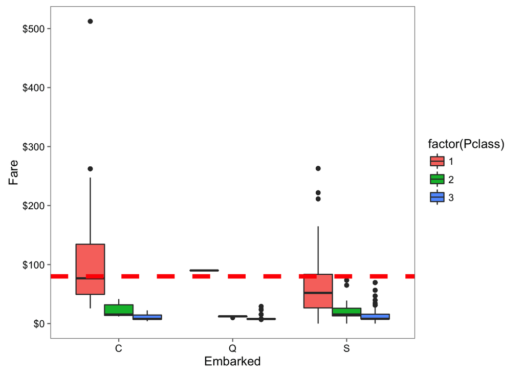

```r
ggplot(Embark_Fare, aes(x = Embarked, y = Fare, fill = factor(Pclass))) +
  geom_boxplot() +
  geom_hline(aes(yintercept=80),
             colour='red', linetype='dashed', lwd=2) +
  scale_y_continuous(labels=dollar_format()) +
  theme_few()
```

We see that the median fare for a first class passenger departing from Charbourg (‘C’) coincides nicely with the $80 paid by our embarkment-deficient passengers. I think we can safely replace the NA values with ‘C’.

```r
combi$Embarked[c(62,830)] = "C"
combi$Embarked <- factor(combi$Embarked)
```

### 3.1.2 Fill in Fare NAs

### Find Fare NAs

```r
summary(combi$Fare)
```

```
##    Min. 1st Qu.  Median    Mean 3rd Qu.    Max.    NA's
##   0.000   7.896  14.450  33.300  31.280 512.300       1
```

```r
which(is.na(combi$Fare))
```

```
## [1] 1044
```

### Show row 1044

```r
combi[1044, ]
```

```
##      PassengerId Survived Pclass               Name  Sex  Age SibSp Parch
## 1044        1044       NA      3 Storey, Mr. Thomas male 60.5     0     0
##      Ticket Fare Cabin Embarked Title Surname FamilySize  FamilyID
## 1044   3701   NA              S    Mr  Storey          1 Singleton
```

### This is a third class passenger who departed from Southampton (‘S’). Let’s visualize Fares among all others sharing their class and embarkment (n = 494).

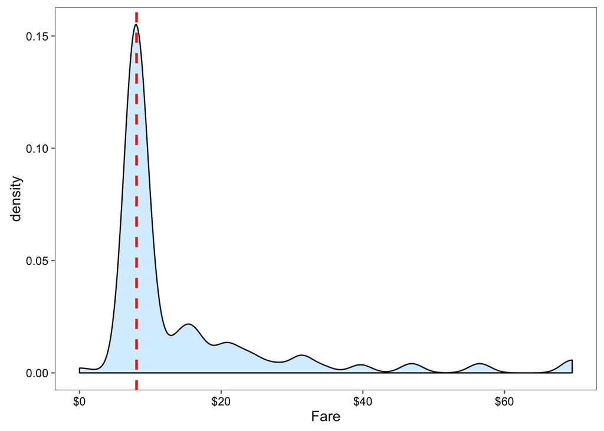

```r
ggplot(combi[combi$Pclass == '3' & combi$Embarked == 'S', ],
  aes(x = Fare)) +
  geom_density(fill = '#99d6ff', alpha=0.4) +
  geom_vline(aes(xintercept=median(Fare, na.rm=T)),
    colour='red', linetype='dashed', lwd=1) +
  scale_x_continuous(labels=dollar_format()) +
  theme_few()
```

From this visualization, it seems quite reasonable to replace the NA Fare value with median for their class and embarkment which is $8.05. ### Replace missing fare value with median fare for class/embarkment

```r
combi$Fare[1044] <- median(combi[combi$Pclass == '3' & combi$Embarked == 'S', ]$Fare, na.rm = TRUE)
```

## 3.2 Fill in Age NAs

```r
summary(combi$Age)
```

```
##    Min. 1st Qu.  Median    Mean 3rd Qu.    Max.    NA's
##    0.17   21.00   28.00   29.88   39.00   80.00     263
```

```r
combi$Age2 <- combi$Age
Agefit <- rpart(Age2 ~ Pclass + Sex + SibSp + Parch + Fare + Embarked + Title + FamilySize,
                data=combi[!is.na(combi$Age2),], method="anova")
combi$Age2[is.na(combi$Age2)] <- predict(Agefit, combi[is.na(combi$Age2),])
```

Let’s compare the results we get with the original distribution of passenger ages to ensure that nothing has gone completely awry.

### Plot Age distributions

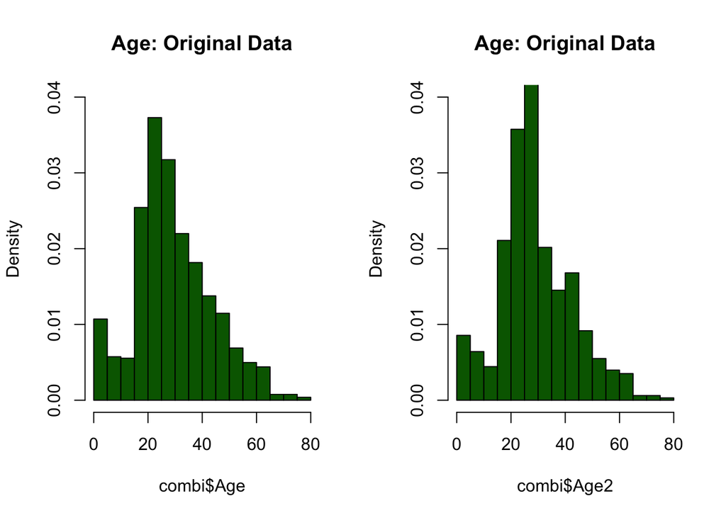

```r
par(mfrow=c(1,2))
hist(combi$Age, freq=F, main='Age: Original Data',
  col='darkgreen', ylim=c(0,0.04))
hist(combi$Age2, freq=F, main='Age: Original Data',
  col='darkgreen', ylim=c(0,0.04))
```

### Things look good, so we replace Age variable from the rpart model

```r
combi$Age <- combi$Age2
combi$Age2 <- NULL
```

### Show new number of missing Age values

```r
sum(is.na(combi$Age))
```

```
## [1] 0
```

## 3.3 More Feature Engineering

### 3.3.1 Create new age-dependent variables: Child and Mother

### First we’ll look at the relationship between age & survival

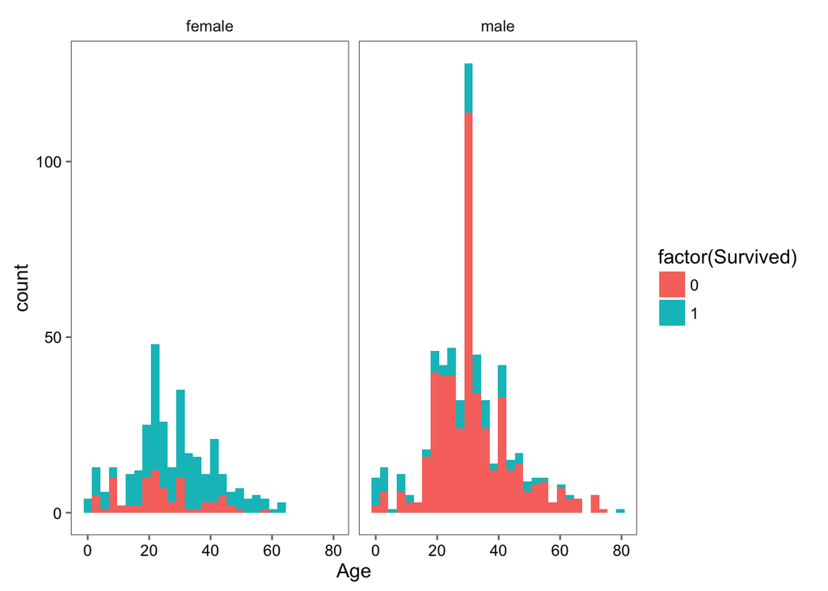

```r
ggplot(combi[1:891,], aes(Age, fill = factor(Survived))) +
  geom_histogram() +
  # I include Sex since we know (a priori) it's a significant predictor
  facet_grid(.~Sex) +
  theme_few()
```

### Create the column child, and indicate whether child or adult

```r
combi$Child[combi$Age < 18] <- 'Child'
combi$Child[combi$Age >= 18] <- 'Adult'
```

### Show counts

```r
table(combi$Child, combi$Survived)
```

```
##
##           0   1
##   Adult 491 278
##   Child  58  64
```

### Create Mother variable

```r
combi$Mother <- 'Not Mother'
combi$Mother[combi$Sex == 'female' & combi$Parch > 0 & combi$Age > 18 & combi$Title != 'Miss'] <- 'Mother'
```

### Show counts

```r
table(combi$Mother, combi$Survived)
```

```
##
##                0   1
##   Mother      16  39
##   Not Mother 533 303
```

### Finish by factorizing our two new factor variables

```r
combi$Child  <- factor(combi$Child)
combi$Mother <- factor(combi$Mother)
```

### All of the variables we care about should be taken care of and there should be no missing data. I’m going to double check just to be sure:

```r
md.pattern(combi)
```

```
##     PassengerId Pclass Sex Age SibSp Parch Ticket Fare Cabin Embarked
## 891           1      1   1   1     1     1      1    1     1        1
## 418           1      1   1   1     1     1      1    1     1        1
##               0      0   0   0     0     0      0    0     0        0
##     Title FamilySize FamilyID Child Mother Survived Name Surname
## 891     1          1        1     1      1        1    0       0    2
## 418     1          1        1     1      1        0    0       0    3
##         0          0        0     0      0      418 1309    1309 3036
```

We have finally finished treating all of the relevant missing values in the Titanic dataset.

### 3.3.2 Calculate Ticket Price (Fare per person)

```r
ticket.count <- aggregate(combi$Ticket, by=list(combi$Ticket), function(x) sum( !is.na(x) ))
combi$Price<-apply(combi, 1, function(x) as.numeric(x["Fare"]) / ticket.count[which(ticket.count[, 1] == x["Ticket"]), 2])

pclass.price<-aggregate(combi$Price, by = list(combi$Pclass), FUN = function(x) median(x, na.rm = T))
combi[which(combi$Price==0), "Price"] <- apply(combi[which(combi$Price==0), ] , 1, function(x) pclass.price[pclass.price[, 1]==x["Pclass"], 2])
```

### 3.3.3 Feature TicketCount

```r
combi$TicketCount<-apply(combi, 1, function(x) ticket.count[which(ticket.count[, 1] == x["Ticket"]), 2])
```

# 4. Prediction

# Split back into test and train sets

```r
train <- combi[1:891,]
test <- combi[892:1309,]
```

# Model setting

```r
set.seed(415)
inTrain<-createDataPartition(train$Survived, p = 0.8)[[1]]
```

## 4.1 Build Random Forest Ensemble

```r
rforest <- randomForest(as.factor(Survived) ~ Pclass + Sex + Age + SibSp
                            + Parch + Fare + Embarked + Title + FamilySize
                            + FamilyID + Price + TicketCount + Child + Mother,
                            data=train, importance=TRUE, ntree=2000)
```

### Show model error

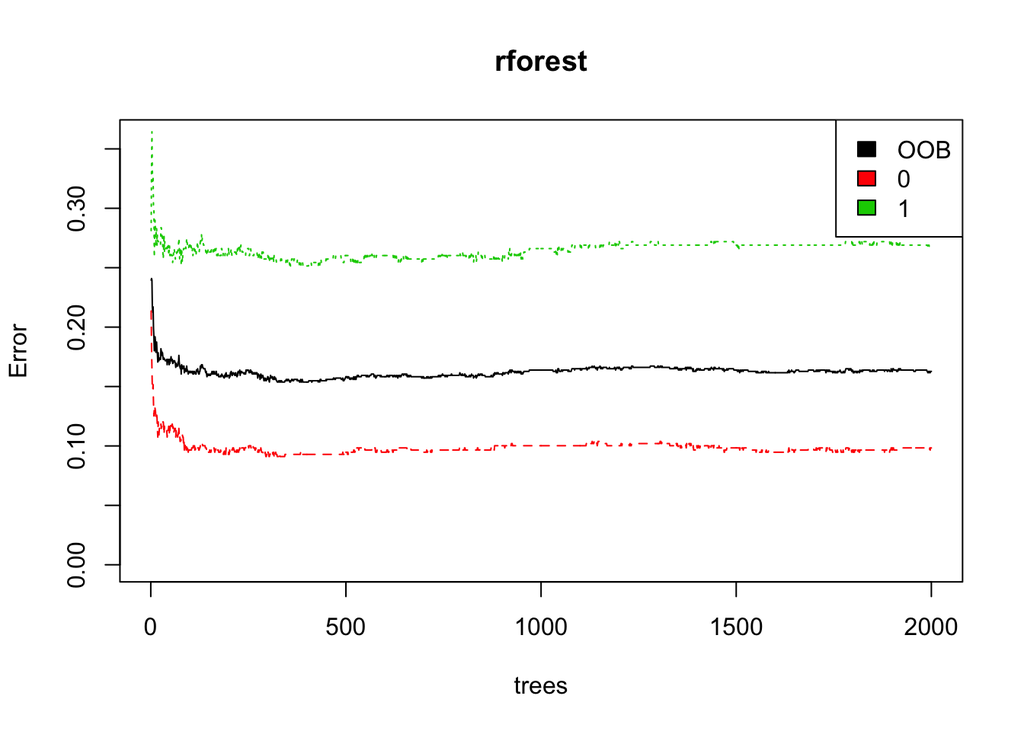

```r
plot(rforest, ylim=c(0,0.36))
legend('topright', colnames(rforest$err.rate), col=1:3, fill=1:3)
```

### Compute accuracy with confusion matrix

```r
confusionMatrix(train[-inTrain,"Survived"], predict(rforest, train[-inTrain,], OOB = TRUE, type = "response"))$overall[1]
```

```
##  Accuracy
## 0.8988764
```

### Make prediction and write to submission file

```r
Prediction <- predict(rforest, test)
submit <- data.frame(PassengerId = test$PassengerId, Survived = Prediction)
write.csv(submit, file = "rforest.csv", row.names = FALSE)
```

## 4.2 Build condition inference tree Random Forest

```r
cforest <- cforest(as.factor(Survived) ~ Pclass + Sex + Age + SibSp
                       + Parch + Fare + Embarked + Title + FamilySize
                       + FamilyID + Price + TicketCount + Child + Mother,
                       data = train[inTrain,], controls=cforest_unbiased(ntree=2000, mtry=3))
```

### Compute accuracy with confusion matrix

```r
confusionMatrix(train[-inTrain,"Survived"], predict(cforest, train[-inTrain,], OOB = TRUE, type = "response"))$overall[1]
```

```
##  Accuracy
## 0.7865169
```

### Make prediction and write to submission file

```r
Prediction <- predict(cforest, test, OOB=TRUE, type = "response")
submit <- data.frame(PassengerId = test$PassengerId, Survived = Prediction)
write.csv(submit, file = "cforest.csv", row.names = FALSE)
```

## 4.3 Fitting a linear model with “TicketCount” converted to a factor variable

```r
glm <- glm(as.factor(Survived) ~ Pclass + Sex + Age + SibSp + Parch + Fare
               + Embarked + Title + FamilySize + Price + I(TicketCount>2)
               + Child + Mother, data=train[inTrain,], family=binomial)
summary(glm)
```

```
##
## Call:
## glm(formula = as.factor(Survived) ~ Pclass + Sex + Age + SibSp +
##     Parch + Fare + Embarked + Title + FamilySize + Price + I(TicketCount >
##     2) + Child + Mother, family = binomial, data = train[inTrain,
##     ])
##
## Deviance Residuals:
##     Min       1Q   Median       3Q      Max
## -2.4833  -0.5541  -0.3605   0.4791   2.5297
##
## Coefficients: (1 not defined because of singularities)
##                          Estimate Std. Error z value Pr(>|z|)
## (Intercept)             4.949e+01  2.287e+03   0.022 0.982732
## Pclass                 -1.224e+00  2.455e-01  -4.987 6.14e-07 ***
## Sexmale                -3.119e+01  1.764e+03  -0.018 0.985890
## Age                    -2.858e-02  1.279e-02  -2.235 0.025431 *
## SibSp                  -5.719e-01  1.523e-01  -3.755 0.000173 ***
## Parch                  -4.618e-01  2.002e-01  -2.307 0.021071 *
## Fare                    2.404e-03  5.606e-03   0.429 0.668074
## EmbarkedQ              -2.250e-01  4.702e-01  -0.478 0.632346
## EmbarkedS              -2.205e-01  2.915e-01  -0.756 0.449354
## TitleLady              -3.136e+01  2.058e+03  -0.015 0.987845
## TitleMaster            -1.325e+01  1.455e+03  -0.009 0.992737
## TitleMiss              -4.459e+01  2.287e+03  -0.020 0.984440
## TitleMr                -1.638e+01  1.455e+03  -0.011 0.991022
## TitleMrs               -4.345e+01  2.287e+03  -0.019 0.984838
## TitleRev               -1.631e+01  1.455e+03  -0.011 0.991058
## TitleSir               -1.575e+01  1.455e+03  -0.011 0.991364
## FamilySize                     NA         NA      NA       NA
## Price                  -2.657e-03  2.442e-02  -0.109 0.913348
## I(TicketCount > 2)TRUE  3.584e-01  4.099e-01   0.875 0.381812
## ChildChild              3.604e-01  5.075e-01   0.710 0.477595
## MotherNot Mother        9.699e-02  6.996e-01   0.139 0.889734
## ---
## Signif. codes:  0 '***' 0.001 '**' 0.01 '*' 0.05 '.' 0.1 ' ' 1
##
## (Dispersion parameter for binomial family taken to be 1)
##
##     Null deviance: 944.03  on 712  degrees of freedom
## Residual deviance: 553.46  on 693  degrees of freedom
## AIC: 593.46
##
## Number of Fisher Scoring iterations: 14
```

### Compute accuracy with confusion matrix

```r
confusionMatrix(train[-inTrain,"Survived"], as.numeric(as.numeric(predict(glm, train[-inTrain,])>0.5)))$overall[1]
```

```
##  Accuracy
## 0.7696629
```

### Make prediction and write to submission file

```r
Prediction <- predict(glm, test, OOB=TRUE, type = "response")
submit <- data.frame(PassengerId = test$PassengerId, Survived = Prediction)
write.csv(submit, file = "glm.csv", row.names = FALSE)
```

## 4.4 Fitting a SVM model

```r
svm <- svm(as.factor(Survived) ~ Pclass + Sex + Age + SibSp + Parch + Fare
               + Embarked + Title + FamilySize + FamilyID + Price + TicketCount
               + Child + Mother, data = train)
summary(svm)
```

```
##
## Call:
## svm(formula = as.factor(Survived) ~ Pclass + Sex + Age + SibSp +
##     Parch + Fare + Embarked + Title + FamilySize + FamilyID +
##     Price + TicketCount + Child + Mother, data = train)
##
##
## Parameters:
##    SVM-Type:  C-classification
##  SVM-Kernel:  radial
##        cost:  1
##       gamma:  0.04166667
##
## Number of Support Vectors:  406
##
##  ( 208 198 )
##
##
## Number of Classes:  2
##
## Levels:
##  0 1
```

### Compute accuracy with confusion matrix

```r
confusionMatrix(train[-inTrain,"Survived"], predict(svm, train[-inTrain,], OOB = TRUE, type = "response"))$overall[1]
```

```
##  Accuracy
## 0.8089888
```

### Make prediction and write to submission file

```r
Prediction <- predict(svm, test, OOB=TRUE, type = "response")
submit <- data.frame(PassengerId = test$PassengerId, Survived = Prediction)
write.csv(submit, file = "svm.csv", row.names = FALSE)
```